# Домашняя работа

Константин Гергенредер

20.12.2020

| **Задачи исследования** |
| --- |
| 1. Исследуйте разные подгруппы клиентов/сотрудников. Выделите подгруппу, которая представляет наибольший интерес, обоснуйте свой выбор |
| 2. Постройте модель для предсказания оттока |
| 3. Выявите основные факторы, которые значимы для предсказания оттока согласно этой модели |
| 4. Предложите, какие действия могла бы предпринять компания, чтобы предотвратить/уменьшить отток. Обоснуйте свои предложения |
| 5. Протестируйте с помощью предсказаний эффект от ваших предложений |

# Часть первая. Разведывательный анализ данных

## 1.1. Проанализируем статус клиентов по странам

Начнем наш разведывательный анализ. Для начала узнаем сколько клиентов остались/ушли по странам. Ответ на этот вопрос даст понять, нужно ли использовать в выделении сегмента данных такую информацию, как страна клиента.

|  | Страна | Ушедшие клиенты | Оставшиеся клиенты |
| --- | --- | --- | --- |
| 1 | France | 810 | 4204 |
| 2 | Germany | 814 | 1695 |
| 3 | Spain | 413 | 2064 |

> **Вывод по 1.1.**

> Как мы видим, в представленном датасете всего 3 страны (Франция, Германия, Испания). Наибольший отток клиентов происходит из Германии и Франции, в то время как клиенты из Испании покидают компанию в два раза реже, чем из Германии и Франции по-отдельности. Так как количество стран всего 3, я не буду использовать данную переменную в построении модели и рекомендации, так как выборка по странам достаточно небольшая.

## 2. Проанализируем распределение клиентов банка по статусу

Для того, чтобы узнать примерное распределение всех клиентов общего датасета построим график, не загружая весь массив данных. Делаем это для того, чтобы узнать общую картину распределения данных.

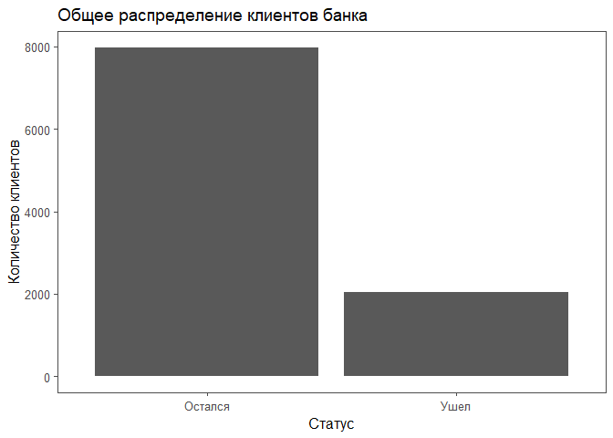

> **Вывод по 1.2.**

> В целом, мы видим, что распределение клиентов оказалось в большую сторону тех, кто остался с компанией. Это говорит о том, что банк не испытывает серьезных проблем с оттоком клиентов, однако для анализа данных наш датасет подходит идеально. Такое распределение данных, к слову, не мешает формулировки реальных рекомендаций для предположительной компании.

# Часть вторая. Исследование оттока клиентов

## 2.1. Выбираем сегмент данных для анализа

В дальнейшем анализе и построении модели я буду использовать условие сегментирования данных, при которых в мою выборку попадают люди от 20 до 50 лет включительно, с положительным балансом банковского счета. Связано это с тем, что меня интересует зрелая клиентская база компании, так как она, теоретически, является наиболее экономически активной.

В качестве условия для выбора переменных, я решил проанализировать данные, используя такие переменные как **Exited** (для предсказания), **IsActiveMember** (для получения информации о том, является ли статус активности клиента важным при анализе оттока), **NumOfProducts** (предположительно, эта переменная должна быть важной при анализе оттока, поэтому, для проверке, выбираем ее), **Age** (возраст из условия сегментации), **Balance** (баланс банковского счета, для дополнительной уверенности в том, что нашли важную переменную).

## 2.2. Строим модель предсказания

В качестве метода я выбрал ctree

[figure not shown]

```
##  Accuracy
## 0.8147139
```

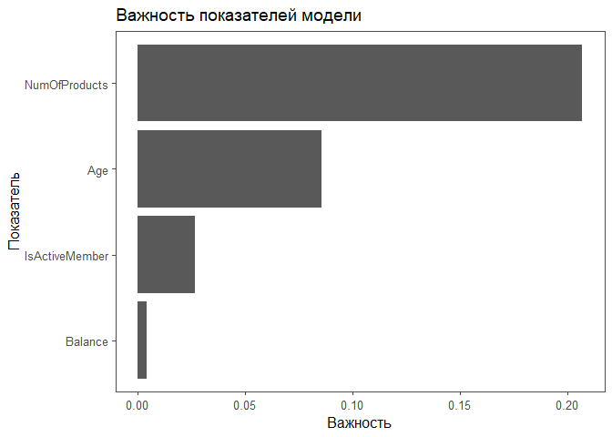

## 2.3. Проанализируем статус клиента по количеству продуктов компании

Из шага 2.2 мы сделали вывод, что наиболее важным фактором является количество продуктов компании, которое использует клиента. Для анализа данного показателя построим сравнительный график количества клиентов по статусу, в зависимости от количества используемых продуктов.

[interactive chart not shown]

> **Вывод по 2.2.**

> Как можно видеть из графика, наиболее распространенным сценарием является наличие одного или двух продуктов у клиента, которым он пользуется. Более двух продуктов используется подгруппой достаточно редко, поэтому в формулировке рекомендаций использовать их не будем. Распределение статусов клиента представленно на графике и количество людей, которые уходят заметно меньше тех, кто остается. В целом, распределение схоже с общим по всем данным выборки. Однако можно видеть, что распределение ушедших клиентов с двумя продуктами меньше, чем с одним. Это позволяет нам сформировать рекомендацию и провести тестирование.

# Часть третья. Экспертные рекомендации по уменьшению оттока клиентов и тестирование

Предположим, что для достижения низких показателей оттока клиентов, менеджмент банка решает вкладываться в развитие своих сервисов, что позволяет перевести **10%** клиентов с 1 банковским продуктом в группу с 2 продуктами. Достичь это можно как с помощьюю увеличения расходов на рекламу своих продуктов, так и с помощью улучшения их качества. В нашем случае число **10%**, как мне кажется, является достижимым и реальным. Сравним получившееся данные.

[interactive chart not shown]

> **Финальный вывод.**

> Проведенный тест нашей рекомендации показал, что количество ушедших клиентов сократиться более чем на 100 человек в пользу оставшихся. Это говорит о том, что если компания добьется перехода 10% своих клиентов на пользование двумя продуктами, это поможет им снизить количество ушедших клиентов на 100 человек. Для большей наглядности мною составлен дэшборд, позволяющий оценить текущую ситуацию в user-friendly варианте. Большое спасибо!

Data Science Minor 2019-2021